# Linear modeling: Multivariable regression

Source: [`vignettes/models.Rmd`](https://github.com/strohne/volker/blob/main/vignettes/models.Rmd)

## One categorical and one metric independent variable

The report_metrics-method generates everything needed for a basic linear model. Other common terms for linear modeling are regression analysis or analysis of variance.

As always with volker package functions, the first parameter is the dataset. The second parameter holds the variable of interest: Provide the variable to be explained (the dependent variable). Set the `model` parameter to `TRUE`. Optionally, output regression diagnostics using the respective parameter.

Other parameters determine the independent variables:  
- The cross parameter (3th parameter) always holds categorical variables such as gender. - The metric parameter (4th parameter) is used to provide a selection of metric independent variables such as age. - In case of interaction terms, add them to the interactions parameter (see example below, e.g. `c(sd_gender * sd_age)`)

```r
report_metrics(data, use_work, cross = sd_gender, metric = sd_age, model = TRUE, diagnostics = TRUE)
```

#### Usage: in professional context

**Table**

| Usage: in professional context | value |
| --- | --- |
| min | 1 |
| q1 | 1 |
| median | 2 |
| q3 | 4 |
| max | 5 |
| mean | 2.4 |
| sd | 1.4 |
| n | 100 |

*n=100.*

**Model: Plot**

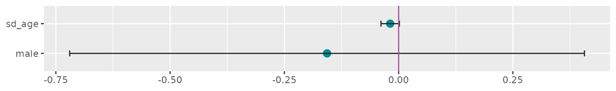

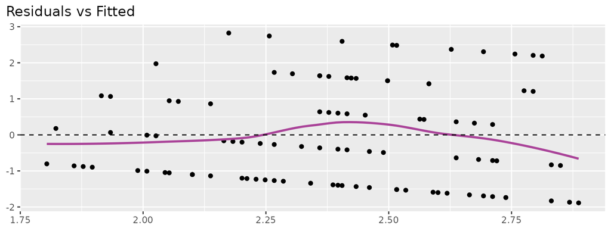

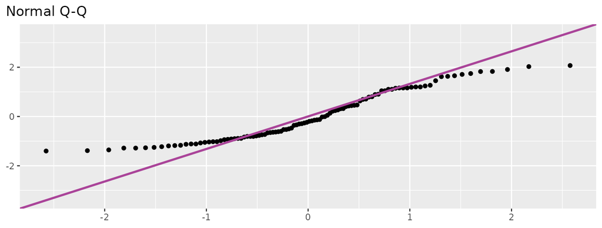

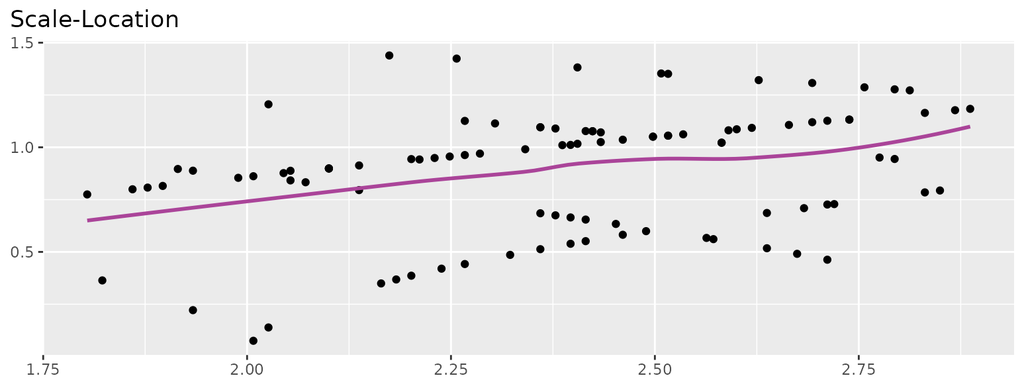

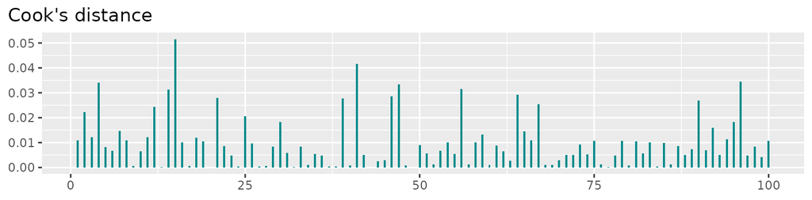

**Model: Table**

| Term | estimate | ci low | ci high | standard beta | standard error | t | p | stars |
| --- | --- | --- | --- | --- | --- | --- | --- | --- |
| (Intercept) | 3.22 | 2.35 | 4.09 |  | 0.44 | 7.36 | 0.000 | *** |
| female (Reference) |  |  |  |  |  |  |  |  |
| male | -0.16 | -0.72 | 0.41 | -0.06 | 0.28 | -0.55 | 0.582 |  |
| sd_age | -0.02 | -0.04 | 0.00 | -0.18 | 0.01 | -1.83 | 0.105 |  |

*Adjusted significance p values with fdr method.*

| Item | Partial Eta Squared | Sum of Squares | Df | F | p | stars | VIF |
| --- | --- | --- | --- | --- | --- | --- | --- |
| sd_gender | 0.00 | 0.58 | 1 | 0.30 | 0.582 |  | 1.02 |
| sd_age | 0.03 | 6.37 | 1 | 3.35 | 0.140 |  | 1.02 |
| Residuals |  | 184.21 | 97 |  |  |  |  |

*Adjusted significance p values with fdr method.*

| Statistic | value |
| --- | --- |
| Adjusted R squared | 0.02 |
| Degrees of freedom | 2 |
| Residuals’ degrees of freedom | 97 |
| AIC | 352.88 |
| F | 2 |
| p | 0.14 |
| stars |  |

An alternative way to this syntax is providing a regression formula instead of variable vectors. See the example down below (experimental, but highly recommended).

## Multiple categorical and metric independent variables

```r
report_metrics(
  data,
  use_work,
  cross  = c(sd_gender, adopter),
  metric = c(starts_with("cg_adoption"), sd_age),
  model      = TRUE,
  diagnostics = TRUE
)
```

#### Usage: in professional context

**Table**

| Usage: in professional context | value |
| --- | --- |
| min | 1 |
| q1 | 1 |
| median | 2 |
| q3 | 4 |
| max | 5 |
| mean | 2.4 |
| sd | 1.4 |
| n | 100 |

*n=100.*

**Model: Plot**

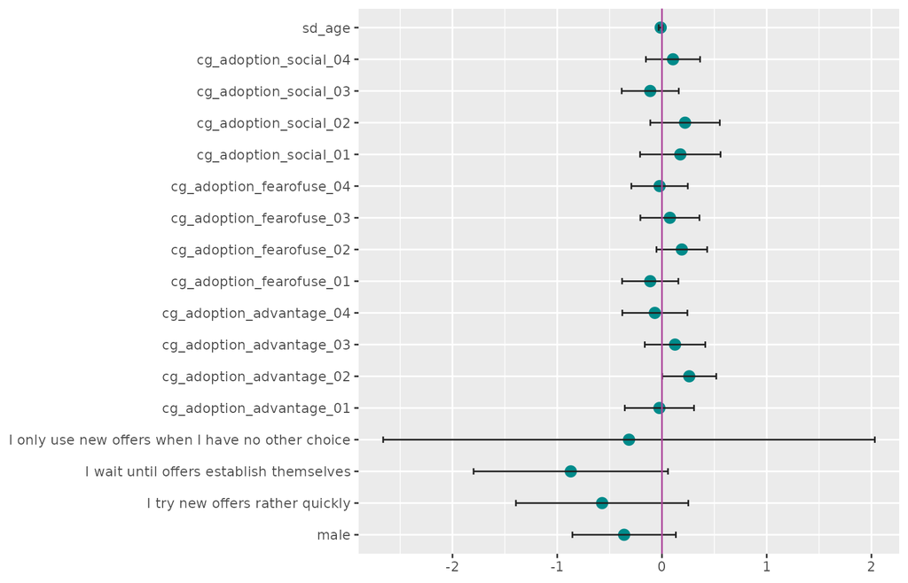

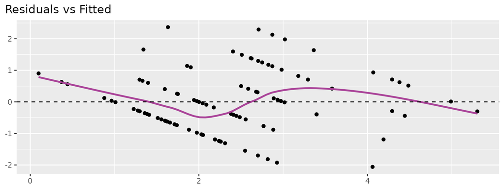

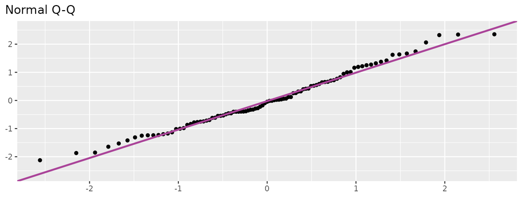

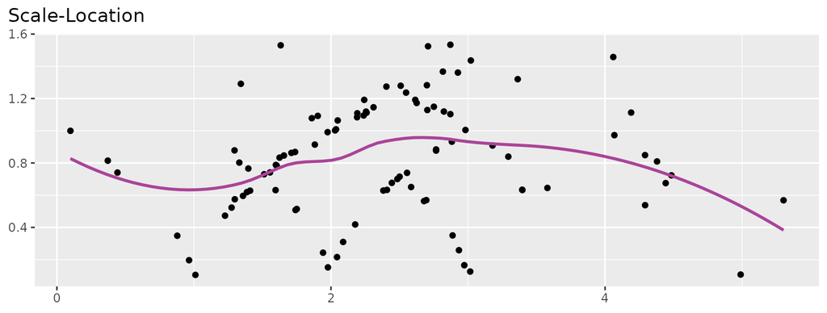

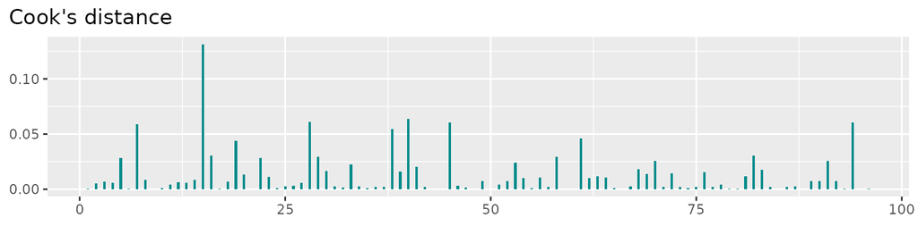

*4 missing case(s) omitted.*

**Model: Table**

| Term | estimate | ci low | ci high | standard beta | standard error | t | p | stars |
| --- | --- | --- | --- | --- | --- | --- | --- | --- |
| (Intercept) | 1.43 | -0.41 | 3.28 |  | 0.93 | 1.54 | 0.443 |  |
| female (Reference) |  |  |  |  |  |  |  |  |
| male | -0.36 | -0.86 | 0.13 | -0.13 | 0.25 | -1.46 | 0.443 |  |
| I try new offers immediately (Reference) |  |  |  |  |  |  |  |  |
| I try new offers rather quickly | -0.57 | -1.39 | 0.25 | -0.20 | 0.41 | -1.38 | 0.443 |  |
| I wait until offers establish themselves | -0.87 | -1.80 | 0.06 | -0.25 | 0.47 | -1.87 | 0.443 |  |
| I only use new offers when I have no other choice | -0.31 | -2.66 | 2.03 | -0.02 | 1.18 | -0.27 | 0.883 |  |
| cg_adoption_advantage_01 | -0.02 | -0.35 | 0.31 | -0.02 | 0.17 | -0.15 | 0.883 |  |
| cg_adoption_advantage_02 | 0.26 | 0.00 | 0.52 | 0.23 | 0.13 | 2.01 | 0.443 |  |
| cg_adoption_advantage_03 | 0.12 | -0.16 | 0.41 | 0.10 | 0.15 | 0.86 | 0.582 |  |
| cg_adoption_advantage_04 | -0.07 | -0.38 | 0.24 | -0.05 | 0.16 | -0.44 | 0.798 |  |
| cg_adoption_fearofuse_01 | -0.11 | -0.38 | 0.16 | -0.09 | 0.13 | -0.83 | 0.582 |  |
| cg_adoption_fearofuse_02 | 0.19 | -0.05 | 0.43 | 0.16 | 0.12 | 1.56 | 0.443 |  |
| cg_adoption_fearofuse_03 | 0.08 | -0.21 | 0.36 | 0.06 | 0.14 | 0.54 | 0.764 |  |
| cg_adoption_fearofuse_04 | -0.02 | -0.29 | 0.25 | -0.02 | 0.14 | -0.17 | 0.883 |  |
| cg_adoption_social_01 | 0.18 | -0.21 | 0.56 | 0.14 | 0.19 | 0.91 | 0.582 |  |
| cg_adoption_social_02 | 0.22 | -0.11 | 0.55 | 0.18 | 0.17 | 1.32 | 0.443 |  |
| cg_adoption_social_03 | -0.11 | -0.38 | 0.16 | -0.09 | 0.14 | -0.82 | 0.582 |  |
| cg_adoption_social_04 | 0.11 | -0.15 | 0.36 | 0.09 | 0.13 | 0.81 | 0.582 |  |
| sd_age | -0.01 | -0.03 | 0.01 | -0.12 | 0.01 | -1.30 | 0.443 |  |

*Adjusted significance p values with fdr method.*

| Item | Partial Eta Squared | Sum of Squares | Df | F | p | stars | GVIF | GVIF^(1/(2*Df)) |
| --- | --- | --- | --- | --- | --- | --- | --- | --- |
| sd_gender | 0.03 | 2.48 | 1 | 2.12 | 0.574 |  | 1.20 | 1.09 |
| adopter | 0.04 | 4.14 | 3 | 1.18 | 0.574 |  | 2.03 | 1.13 |
| cg_adoption_advantage_01 | 0.00 | 0.03 | 1 | 0.02 | 0.883 |  | 2.44 | 1.56 |
| cg_adoption_advantage_02 | 0.05 | 4.72 | 1 | 4.04 | 0.574 |  | 1.99 | 1.41 |
| cg_adoption_advantage_03 | 0.01 | 0.86 | 1 | 0.74 | 0.574 |  | 2.01 | 1.42 |
| cg_adoption_advantage_04 | 0.00 | 0.22 | 1 | 0.19 | 0.767 |  | 2.00 | 1.41 |
| cg_adoption_fearofuse_01 | 0.01 | 0.81 | 1 | 0.69 | 0.574 |  | 1.90 | 1.38 |
| cg_adoption_fearofuse_02 | 0.03 | 2.84 | 1 | 2.43 | 0.574 |  | 1.66 | 1.29 |
| cg_adoption_fearofuse_03 | 0.00 | 0.33 | 1 | 0.29 | 0.742 |  | 1.77 | 1.33 |
| cg_adoption_fearofuse_04 | 0.00 | 0.03 | 1 | 0.03 | 0.883 |  | 1.80 | 1.34 |
| cg_adoption_social_01 | 0.01 | 0.96 | 1 | 0.82 | 0.574 |  | 3.83 | 1.96 |
| cg_adoption_social_02 | 0.02 | 2.05 | 1 | 1.75 | 0.574 |  | 3.05 | 1.75 |
| cg_adoption_social_03 | 0.01 | 0.78 | 1 | 0.67 | 0.574 |  | 2.05 | 1.43 |
| cg_adoption_social_04 | 0.01 | 0.77 | 1 | 0.66 | 0.574 |  | 2.12 | 1.46 |
| sd_age | 0.02 | 1.98 | 1 | 1.69 | 0.574 |  | 1.36 | 1.17 |
| Residuals |  | 91.18 | 78 |  |  |  |  |  |

*Adjusted significance p values with fdr method.*

| Statistic | value |
| --- | --- |
| Adjusted R squared | 0.4 |
| Degrees of freedom | 17 |
| Residuals’ degrees of freedom | 78 |
| AIC | 305.49 |
| F | 4.72 |
| p | 0 |
| stars | *** |

*4 missing case(s) omitted.*

## Index as independent variable

```r
data |>
  add_index(starts_with("cg_adoption")) |>
  report_metrics(
    use_work,
    cross  = c(sd_gender, adopter),
    metric = c(idx_cg_adoption, sd_age),
    model  = TRUE
  )
```

#### Usage: in professional context

**Plot**

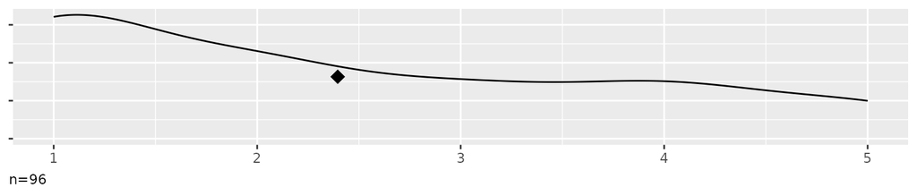

*4 missing case(s) omitted.*

**Table**

| Usage: in professional context | value |
| --- | --- |
| min | 1 |
| q1 | 1 |
| median | 2 |
| q3 | 4 |
| max | 5 |
| mean | 2.4 |
| sd | 1.4 |
| n | 96 |

*n=96. 4 missing case(s) omitted.*

**Model: Plot**

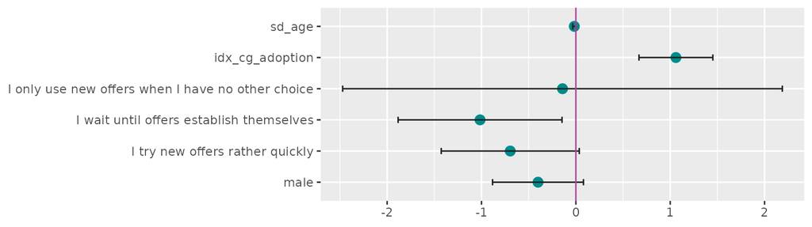

*4 missing case(s) omitted.*

**Model: Table**

| Term | estimate | ci low | ci high | standard beta | standard error | t | p | stars |
| --- | --- | --- | --- | --- | --- | --- | --- | --- |
| (Intercept) | 0.91 | -0.78 | 2.59 |  | 0.85 | 1.07 | 0.336 |  |
| female (Reference) |  |  |  |  |  |  |  |  |
| male | -0.40 | -0.88 | 0.08 | -0.14 | 0.24 | -1.65 | 0.142 |  |
| I try new offers immediately (Reference) |  |  |  |  |  |  |  |  |
| I try new offers rather quickly | -0.70 | -1.43 | 0.04 | -0.24 | 0.37 | -1.89 | 0.109 |  |
| I wait until offers establish themselves | -1.02 | -1.88 | -0.15 | -0.30 | 0.44 | -2.32 | 0.079 | . |
| I only use new offers when I have no other choice | -0.14 | -2.47 | 2.19 | -0.01 | 1.17 | -0.12 | 0.904 |  |
| idx_cg_adoption | 1.06 | 0.67 | 1.45 | 0.49 | 0.20 | 5.38 | 0.000 | *** |
| sd_age | -0.02 | -0.03 | 0.00 | -0.16 | 0.01 | -1.95 | 0.109 |  |

*Adjusted significance p values with fdr method.*

| Item | Partial Eta Squared | Sum of Squares | Df | F | p | stars | GVIF | GVIF^(1/(2*Df)) |
| --- | --- | --- | --- | --- | --- | --- | --- | --- |
| sd_gender | 0.03 | 3.32 | 1 | 2.73 | 0.136 |  | 1.10 | 1.05 |
| adopter | 0.06 | 6.91 | 3 | 1.90 | 0.136 |  | 1.38 | 1.06 |
| idx_cg_adoption | 0.25 | 35.14 | 1 | 28.98 | 0.000 | *** | 1.26 | 1.12 |
| sd_age | 0.04 | 4.61 | 1 | 3.80 | 0.109 |  | 1.05 | 1.02 |
| Residuals |  | 107.93 | 89 |  |  |  |  |  |

*Adjusted significance p values with fdr method.*

| Statistic | value |
| --- | --- |
| Adjusted R squared | 0.38 |
| Degrees of freedom | 6 |
| Residuals’ degrees of freedom | 89 |
| AIC | 299.68 |
| F | 10.59 |
| p | 0 |
| stars | *** |

*4 missing case(s) omitted.*

## Interactions

```r
data |>
  report_metrics(
    use_work,
    cross        = c(sd_gender),
    metric       = c(sd_age),
    interactions = c(sd_gender * sd_age),
    model = TRUE
  )
```

#### Usage: in professional context

**Table**

| Usage: in professional context | value |
| --- | --- |
| min | 1 |
| q1 | 1 |
| median | 2 |
| q3 | 4 |
| max | 5 |
| mean | 2.4 |
| sd | 1.4 |
| n | 100 |

*n=100.*

**Model: Plot**

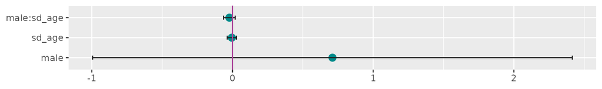

**Model: Table**

| Term | estimate | ci low | ci high | standard beta | standard error | t | p | stars |
| --- | --- | --- | --- | --- | --- | --- | --- | --- |
| (Intercept) | 2.70 | 1.40 | 4.00 |  | 0.65 | 4.14 | 0.000 | *** |
| female (Reference) |  |  |  |  |  |  |  |  |
| male | 0.71 | -0.99 | 2.42 | 0.25 | 0.86 | 0.83 | 0.547 |  |
| sd_age | 0.00 | -0.04 | 0.03 | -0.05 | 0.02 | -0.29 | 0.776 |  |
| male:sd_age | -0.02 | -0.06 | 0.02 | -0.37 | 0.02 | -1.07 | 0.547 |  |

*Adjusted significance p values with fdr method.*

| Item | Partial Eta Squared | Sum of Squares | Df | F | p | stars | VIF |
| --- | --- | --- | --- | --- | --- | --- | --- |
| sd_gender | 0.00 | 0.58 | 1 | 0.31 | 0.582 |  | 9.34 |
| sd_age | 0.03 | 6.37 | 1 | 3.36 | 0.210 |  | 2.68 |
| sd_gender:sd_age | 0.01 | 2.17 | 1 | 1.14 | 0.431 |  | 11.96 |
| Residuals |  | 182.04 | 96 |  |  |  |  |

*Adjusted significance p values with fdr method.*

| Statistic | value |
| --- | --- |
| Adjusted R squared | 0.02 |
| Degrees of freedom | 3 |
| Residuals’ degrees of freedom | 96 |
| AIC | 353.69 |
| F | 1.71 |
| p | 0.17 |
| stars |  |

## The formula interface

If you are used to the formula interface of R, the same output can be generated using a formula instead of the term lists:

- The left-hand side of the formula is the outcome variable
- The right-hand side contains predictors. Multiple predictors are connected with `+`. Interaction terms are added using `*`. Factor values and logical values are treated as categorical, other terms as metric.

```r
data |>
  report_metrics(use_work ~ sd_gender * sd_age)
```

#### Usage: in professional context

**Table**

| Usage: in professional context | value |
| --- | --- |
| min | 1 |
| q1 | 1 |
| median | 2 |
| q3 | 4 |
| max | 5 |
| mean | 2.4 |
| sd | 1.4 |
| n | 100 |

*n=100.*

**Model: Plot**

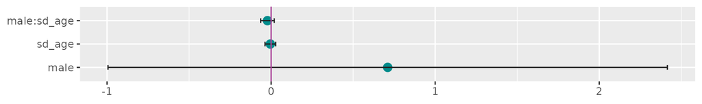

**Model: Table**

| Term | estimate | ci low | ci high | standard beta | standard error | t | p | stars |
| --- | --- | --- | --- | --- | --- | --- | --- | --- |
| (Intercept) | 2.70 | 1.40 | 4.00 |  | 0.65 | 4.14 | 0.000 | *** |
| female (Reference) |  |  |  |  |  |  |  |  |
| male | 0.71 | -0.99 | 2.42 | 0.25 | 0.86 | 0.83 | 0.547 |  |
| sd_age | 0.00 | -0.04 | 0.03 | -0.05 | 0.02 | -0.29 | 0.776 |  |
| male:sd_age | -0.02 | -0.06 | 0.02 | -0.37 | 0.02 | -1.07 | 0.547 |  |

*Adjusted significance p values with fdr method.*

| Item | Partial Eta Squared | Sum of Squares | Df | F | p | stars | VIF |
| --- | --- | --- | --- | --- | --- | --- | --- |
| sd_gender | 0.00 | 0.58 | 1 | 0.31 | 0.582 |  | 9.34 |
| sd_age | 0.03 | 6.37 | 1 | 3.36 | 0.210 |  | 2.68 |
| sd_gender:sd_age | 0.01 | 2.17 | 1 | 1.14 | 0.431 |  | 11.96 |
| Residuals |  | 182.04 | 96 |  |  |  |  |

*Adjusted significance p values with fdr method.*

| Statistic | value |
| --- | --- |
| Adjusted R squared | 0.02 |
| Degrees of freedom | 3 |
| Residuals’ degrees of freedom | 96 |
| AIC | 353.69 |
| F | 1.71 |
| p | 0.17 |
| stars |  |

## Add predicted values to data frame

To use the predicted values, first add the model. This will result in a new column with the prefix “prd_”.

Instead of using the report-method, you can explicitly request the results using `model_tab()` and `model_plot()`.

```r
data <- add_model(
  data,
  use_work,
  categorical = c(sd_gender),
  metric = c(use_private),
  interactions = c(sd_gender * use_private)
)

model_tab(data, prd_use_work)
```

| Term | estimate | ci low | ci high | standard beta | standard error | t | p | stars |
| --- | --- | --- | --- | --- | --- | --- | --- | --- |
| (Intercept) | 1.63 | 0.46 | 2.80 |  | 0.59 | 2.78 | 0.027 | * |
| female (Reference) |  |  |  |  |  |  |  |  |
| male | -0.87 | -2.35 | 0.61 | -0.31 | 0.75 | -1.16 | 0.276 |  |
| use_private | 0.33 | -0.07 | 0.73 | 0.24 | 0.20 | 1.63 | 0.215 |  |
| male:use_private | 0.29 | -0.24 | 0.82 | 0.30 | 0.27 | 1.10 | 0.276 |  |

| Item | Partial Eta Squared | Sum of Squares | Df | F | p | stars | VIF |
| --- | --- | --- | --- | --- | --- | --- | --- |
| sd_gender | 0.00 | 0.26 | 1 | 0.15 | 0.697 |  | 7.84 |
| use_private | 0.13 | 24.34 | 1 | 14.23 | 0.001 | *** | 2.39 |
| sd_gender:use_private | 0.01 | 2.05 | 1 | 1.20 | 0.414 |  | 8.48 |
| Residuals |  | 164.19 | 96 |  |  |  |  |

| Statistic | value |
| --- | --- |
| Adjusted R squared | 0.12 |
| Degrees of freedom | 3 |
| Residuals’ degrees of freedom | 96 |
| AIC | 343.37 |
| F | 5.38 |
| p | 0 |
| stars | *** |

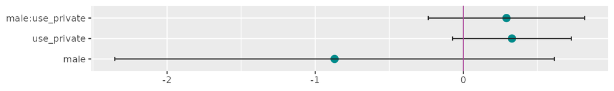

```r
model_plot(data, prd_use_work)
```

After adding predicted values, you can use them as any other column. The following example generates a scatter plot to inspect how well the predicted values correlate with the true values.

#### Usage: in professional context

**Plot**

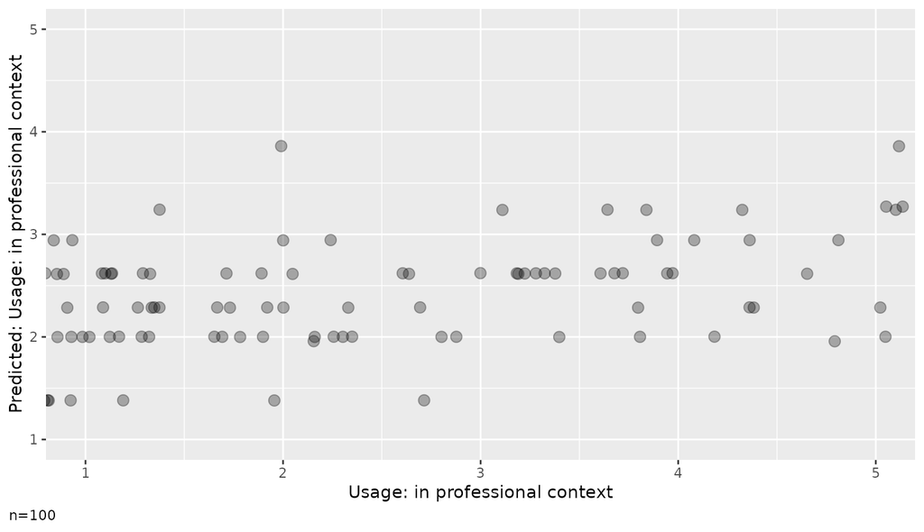

**Table**

| Item 1 | Item 2 | n | Pearson’s r |
| --- | --- | --- | --- |
| Usage: in professional context | Predicted: Usage: in professional context | 100 | 0.38 |

*n=100.*